# Tutorial

Jamey McDowell and Steffani Gomez

March 13, 2018

## Introduction

This tutorial is for those already familiar with using dataframes in R. This assumes familiarity with subsetting and the library `dplyr` for data manipulation.

In R there are two primary time series objects that are used. These objects are either `ts` or `xts`.

For the purpose of this tutorial, we are going to focus on using `ts` to create time-series objects. R preloads this function through the `stats` package.

### Making a Univariate Time-Series Objects

Columns are variables, observations are rows. You can view a time-series object the same way as a matrix or dataframe. At its core, a time-series object is a vector (univariate) or matrix (multivariate). Dataframes are implicitly converted to matrices before they are actually converted to a time-series object.

Consider, for example, loading the co2_ts.csv file:

```r
co2_df <- read.csv("co2_ts.csv")
class(co2_df)
```

```
[1] "data.frame"
```

When first loaded, note that R saves the file as a data frame. Therefore we must convert the data frame to a time series object. To make a time series object, we need to know the start, end, and frequency for our data. For this csv file, the data is already sorted for us. If this were not the case, we could use the `arrange` function from `dplyr` package to sort the data instead. Because we already have the month number in one column and the year column in another, we can sort the data accordingly:

```r
library(dplyr)
co2_df <- co2_df %>%
  arrange(Year, Month)
```

By visually inspecting this newly arranged data, we see that the dataset runs from `05-1974` to `09-1987`. Therefore we will specify the start and end dates accordingly when making the time series objects. Because we are dealing with monthly data, we set the frequency argument to 12.

We also see that we are dealing with univariate data. Therefore when making the time series object, we only need to take the `CO2` column from the data frame.

```r
co2_ts <- ts(co2_df$CO2, start = c(1974, 5), end = c(1987, 9), frequency = 12)
```

This code took only the `CO2` column from our original data frame since this is the only column that contains data not pertaining to the date.

Our new object is of type `ts`.

```r
class(co2_ts)
```

```
[1] "ts"
```

## Libraries

```r
library(forecast)
library(sarima) # arima/arma models
library(ggplot2) # plotting
library(lubridate) # date subsetting
library(astsa) # arima/arma models
library(tseries) # ADF test
```

THe primary library used for forecasting in R is the `forecast` package. The full uses of this package can be found at https://cran.r-project.org/web/packages/forecast/forecast.pdf.

We can use the `sarima` library to handle ARMA and ARIMA models for us, allowing us to easier adjust our parameters.

## EDA Tutorial

We can use the basic plot function to visualize the data set:

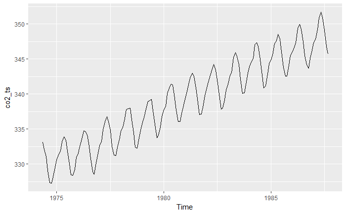

```r
autoplot(co2_ts)
```

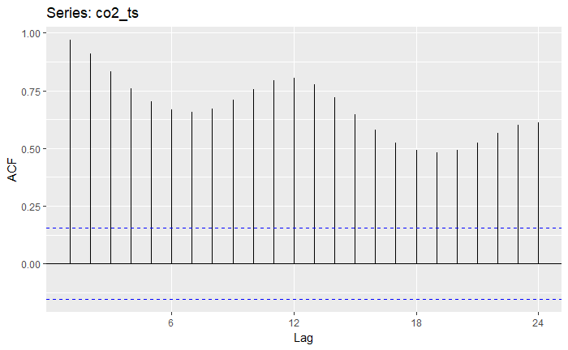

```r
ggAcf(co2_ts)
```

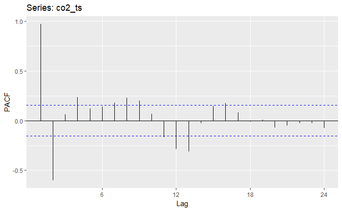

```r
ggPacf(co2_ts)
```

## Models

This is an example of forecasting in R.

```r
solarpv_df <- read.csv("solarpv.csv")
solarpv_df
```

When we take a look at the dataset we have just loaded, the first thing we must do is ensure that our date is in the proper date format and that R recognizes that it is a date (i.e. make sure the dates belong to the Date class and are encoded properly). We use the `lapply` function to apply the `class` function and see what class each variable/column belongs to.

```r
# using the lapply function to look at the data type of each variable, and we see that our date is not in
# a date format
lapply(solarpv_df, class)
```

As we can see, the dates in the dataset are not encoded properly and need to be changed to dates in the Date class. https://www.statmethods.net/input/dates.html has a great explanation on the different date encodings to be used with `as.Date`.

```r
# to transform, we are going to need the as.Date() function
solarpv_df$EDT <- as.Date(solarpv_df$EDT, "%a, %d %b %Y")
lapply(solarpv_df, class)

# https://www.statmethods.net/input/dates.html
# now we can see we transformed the date properly
```

The first thing we do is plot the univariate time series, as well the ACF (autocorrelative function) and the PACF(partial autocorrelative function) for the series.

```r
# here we plot the series, a univariate series as we can see
plot(y=solarpv_df$kW_Gen, x=solarpv_df$EDT, type='l')

ggAcf(solarpv_df$kW_Gen, lag.max = 24)
ggPacf(solarpv_df$kW_Gen, lag.max = 24)
```

[output not shown]

Next, we determine whether the univariate time series is a white noise, using the Ljung-Box method, and parameters set. We also take a look at the mean, standard deviation, and length of the time series.

```r
# autocorrelation white noise test
whiteNoiseTest(autocorrelations(solarpv_df$kW_Gen, maxlag = 24), h0 = "iid", nlags = c(6,12,18,24), x = x, method = "LjungBox")

mean(solarpv_df$kW_Gen)
sd(solarpv_df$kW_Gen)
length(solarpv_df$kW_Gen)
```

[output not shown]

```r
#estimate arima model
mod.1 <- arima(solarpv_df$kW_Gen, order=c(1,0,0), method = "ML")
mod.2 <- sarima(solarpv_df$kW_Gen, p = 1, d = 0, q = 0)
summary(mod.1)
summary(mod.2)
```

[output not shown]

Here we evaluate the model, looking at the ACF, PACF, and white noise test on the residuals.

```r
#diagnose arima model
ggAcf(mod.1$residuals)
ggPacf(mod.1$residuals)
Box.test(mod.1$residuals)
```

[output not shown]

```r
solarpv_df <- read.csv("solarpv.csv")
# using the lapply function to look at the data type of each variable, and we see that our date is not in
# a date format
lapply(solarpv_df, class)
```

```
$EDT
[1] "factor"

$kW_Gen
[1] "numeric"

$Cloud_Cover
[1] "numeric"
```

```r
# to transform, we can use the as.Date() function
solarpv_df$EDT <- as.Date(solarpv_df$EDT, "%a, %d %b %Y")
lapply(solarpv_df, class)
```

```
$EDT
[1] "Date"

$kW_Gen
[1] "numeric"

$Cloud_Cover
[1] "numeric"
```

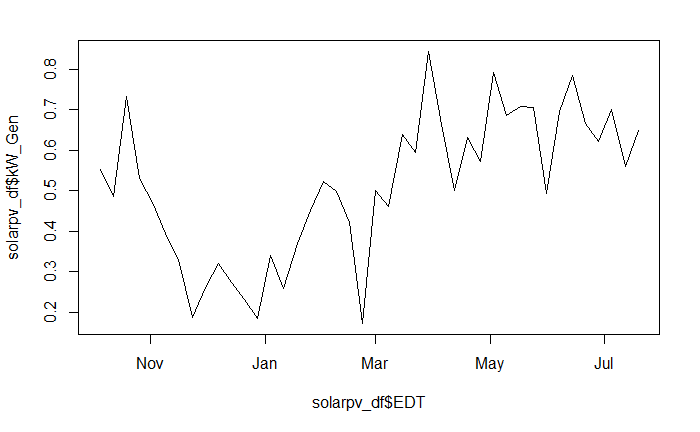

```r
# https://www.statmethods.net/input/dates.html
# now we can see we transformed the date properly
# here we plot the series, a univariate series as we can see
plot(y=solarpv_df$kW_Gen, x=solarpv_df$EDT, type='l')
```

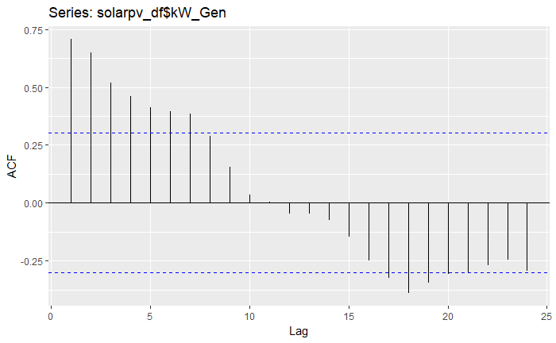

```r
ggAcf(solarpv_df$kW_Gen, lag.max = 24)
```

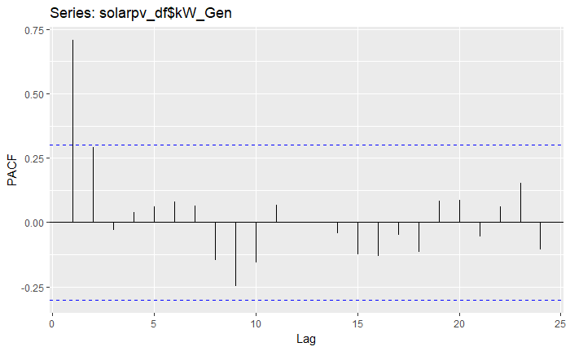

```r
ggPacf(solarpv_df$kW_Gen, lag.max = 24)
```

```r
# autocorrelation white noise test
whiteNoiseTest(autocorrelations(solarpv_df$kW_Gen, maxlag = 24), h0 = "iid", nlags = c(6,12,18,24), x = x, method = "LjungBox")
```

```
$test
         ChiSq DF       pvalue
[1,]  81.65128  6 1.628370e-15
[2,]  95.52573 12 4.168860e-15
[3,] 121.53443 18 2.153171e-17
[4,] 168.57518 24 1.087627e-23
attr(,"method")
[1] "LjungBox"

$ci
            int
 [1,] -0.302429 0.302429
 [2,] -0.302429 0.302429
 [3,] -0.302429 0.302429
 [4,] -0.302429 0.302429
```

[output cut: 22 more lines]

```r
mean(solarpv_df$kW_Gen)
```

```
[1] 0.5110783
```

```r
sd(solarpv_df$kW_Gen)
```

```
[1] 0.181538
```

```r
length(solarpv_df$kW_Gen)
```

```
[1] 42
```

```r
# Augmented Dicky Fuller Test
adf.test(solarpv_df$kW_Gen)
```

```
    Augmented Dickey-Fuller Test

data:  solarpv_df$kW_Gen
Dickey-Fuller = -3.2997, Lag order = 3, p-value = 0.08533
alternative hypothesis: stationary
```

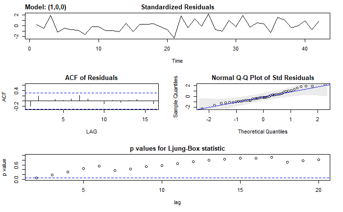

```r
#estimate arima model
mod.1 <- arima(solarpv_df$kW_Gen, order=c(1,0,0), method = "ML")
mod.2 <- sarima(solarpv_df$kW_Gen, p = 1, d = 0, q = 0)
```

```r
summary(mod.1)
```

```
Call:
arima(x = solarpv_df$kW_Gen, order = c(1, 0, 0), method = "ML")

Coefficients:
         ar1  intercept
      0.7039     0.5202
s.e.  0.1051     0.0621

sigma^2 estimated as 0.01574:  log likelihood = 27.24,  aic = -48.49

Training set error measures:
                        ME      RMSE      MAE       MPE   MAPE      MASE
Training set -0.0007846569 0.1254658 0.101899 -9.648602 25.177 0.8939698
                   ACF1
Training set -0.1873829
```

```r
summary(mod.2)
```

```
                   Length Class  Mode
fit                14     Arima  list
degrees_of_freedom  1     -none- numeric
ttable              8     -none- numeric
AIC                 1     -none- numeric
AICc                1     -none- numeric
BIC                 1     -none- numeric
```

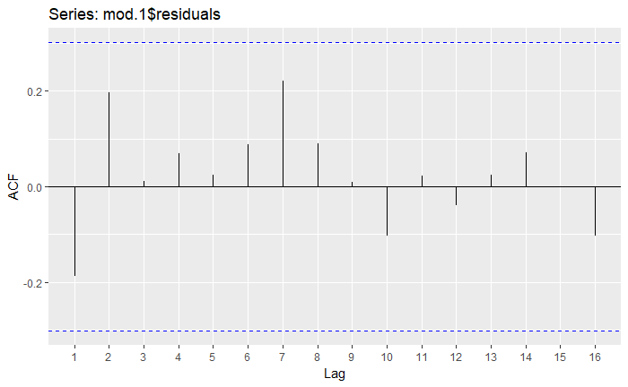

```r
#diagnose arima model
ggAcf(mod.1$residuals)
```

```r
ggPacf(mod.1$residuals)
```

[figure not shown]

```r
Box.test(mod.1$residuals)
```

```
    Box-Pierce test

data:  mod.1$residuals
X-squared = 1.4747, df = 1, p-value = 0.2246
```

## Messy Data Examples

### ch1_demodat.csv

Consider the ch1_demodat.csv file from class on March 15. This data has both missing values and a difficult-to-parse `dtdate` variable. We will first work on the `dtdate` variable by using the `strptime` function.

```r
ch1_demodat <- read.csv("ch1_demodat.csv")
ch1_demodat$time <- as.POSIXct(strptime(ch1_demodat$dtdate, format = '%d%b%Y:%T'))
```

Note the weird format argument. Look more at the `strptime` function for more informration on how I chose this by typing “?strptime” in the console.

The primary reasoning here is that R stores time variables as either a `POSIXlt` object or a `POSIXct` object. In this code, we converted first to a `POSIXlt` object before then converting to a `POSIXct` object.

There are some differences between the two objects but for the purposes of this tutorial we will not go into them.

We have the hourly data but we want to work with this at the monthly level. To aggregate to the monthly level, we can use the `group_by` function in conjunction with the `floor_date` function, as demonstrated below.

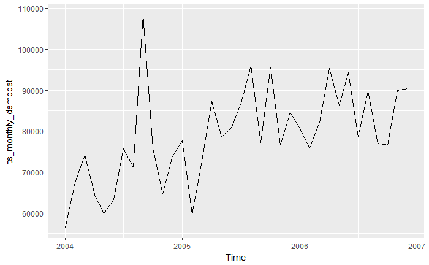

```r
monthly_demodat <- ch1_demodat %>%
  group_by(time = floor_date(time, "month")) %>%
  summarize(units = sum(units, na.rm = TRUE))
ts_monthly_demodat <- ts(monthly_demodat$units, start = c(2004, 01, 01), frequency = 12)
autoplot(ts_monthly_demodat)
```